# A Hotel Cancellation Prediction Tool

## 3.8 Model Testing

The best way to convey the performance of ours models is to display a confusion matrix. Here we will print the results of our model fitted on both the training data subset (left) and the test subset (right)

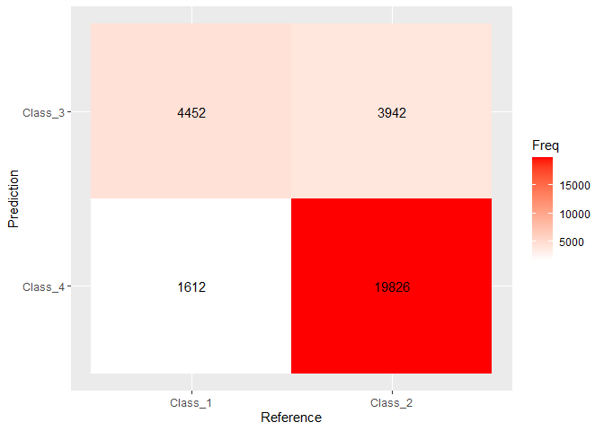

```r
  # Prediction on the training data set
  pred <- predict(final_model_resort_3,data_train__resort,type='response')
  data_train__resort <- data_train__resort %>%
    mutate(pred = pred) %>%
    mutate(pred_binary = as.factor(ifelse(pred >= 0.5, 1, 0)))

  cm <- confusionMatrix(data=data_train__resort$pred_binary,reference=data_train__resort$is_canceled,positive='1')

  plt <- as.data.frame(cm$table)
  plt$Prediction <- factor(plt$Prediction, levels=rev(levels(plt$Prediction)))

  ggplot(plt, aes(Prediction,Reference, fill = Freq)) +
    geom_tile() + geom_text(aes(label=Freq)) +
    scale_fill_gradient(low="white", high="red") +
    labs(x = "Reference",y = "Prediction") +
    scale_x_discrete(labels=c("Class_1","Class_2","Class_3","Class_4")) +
    scale_y_discrete(labels=c("Class_4","Class_3","Class_2","Class_1"))
```

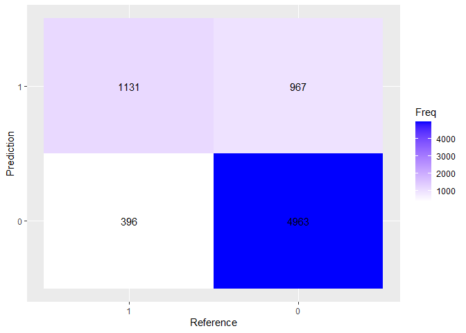

```r
  pred_test <- predict(final_model_resort_3, data_test__resort, type='response')
  data_test__resort <- data_test__resort %>%
    mutate(pred = pred_test) %>%
    mutate(pred_binary = as.factor(ifelse(pred >= 0.5, 1, 0)))

  cm <- confusionMatrix(data = data_test__resort$pred_binary, reference = data_test__resort$is_canceled, positive='1')

  plt <- as.data.frame(cm$table)
  plt$Prediction <- factor(plt$Prediction, levels=rev(levels(plt$Prediction)))

  ggplot(plt, aes(Prediction,Reference, fill = Freq)) +
    geom_tile() + geom_text(aes(label = Freq)) +
    scale_fill_gradient(low="white", high="blue") +
    labs(x = "Reference",y = "Prediction")
```

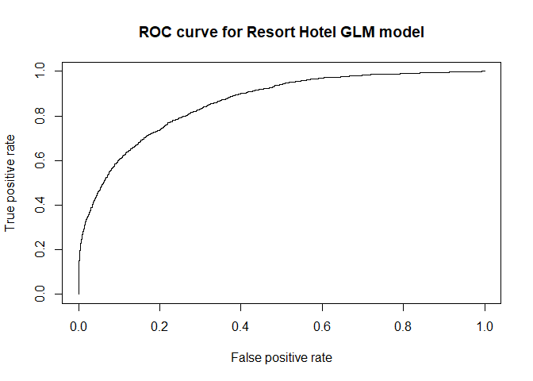

```r
predicts <- prediction(as.numeric(data_test__resort$pred),as.numeric(data_test__resort$is_canceled))
roc <- performance(predicts,"tpr", "fpr")
plot(roc,main="ROC curve for Resort Hotel GLM model")
```

```r
auc_ROCR <- performance(predicts, measure = "auc")
auc_ROCR <- auc_ROCR@y.values[[1]]
print(paste("AUC value for logistic regression: ",auc_ROCR))
```

```
[1] "AUC value for logistic regression:  0.861377899957485"
```

> ✨ **CONCLUSION:** This concludes the analysis on the Resort Hotel type.

## 3.9 Second Study - City Hotel

As mentioned above, this phase will reproduce the analysis on the second hotel type.

```r
  modZero <- glm(is_canceled ~ 1, data = data_train__city, family = "binomial")

  full_model_city <- glm(is_canceled ~
    lead_time + arrival_date_month + adults + country + market_segment + is_repeated_guest + previous_cancellations + deposit_type +
    days_in_waiting_list + customer_type + adr + required_car_parking_spaces + temp + total_nights_stayed + mismatched_room +
    agent + has_special_request + has_booking_change + has_children + meal,
    data = data_train__city, family = "binomial")

  step_city <- stepAIC(modZero, direction = "forward", scope = list(lower = modZero, upper = full_model_city), k = 2, trace = F)
  step_city$anova
```

```
Stepwise Model Path
Analysis of Deviance Table

Initial Model:
is_canceled ~ 1

Final Model:
is_canceled ~ deposit_type + agent + country + has_special_request +
    previous_cancellations + mismatched_room + required_car_parking_spaces +
    lead_time + customer_type + has_booking_change + total_nights_stayed +
    market_segment + is_repeated_guest + adr + meal + arrival_date_month +
    days_in_waiting_list + has_children + adults + temp

                            Step Df     Deviance Resid. Df Resid. Dev      AIC
1                                                    59017   80414.41 80416.41
2                 + deposit_type  2 18751.029542     59015   61663.38 61669.38
3                        + agent  3  2937.433293     59012   58725.94 58737.94
4                      + country  7  3717.062838     59005   55008.88 55034.88
5          + has_special_request  1  3340.177198     59004   51668.70 51696.70
6       + previous_cancellations  4  2020.590423     59000   49648.11 49684.11
7              + mismatched_room  1  1555.103392     58999   48093.01 48131.01
8  + required_car_parking_spaces  1  1099.032864     58998   46993.98 47033.98
9                    + lead_time  1   800.559251     58997   46193.42 46235.42
10               + customer_type  3   800.452916     58994   45392.96 45440.96
11          + has_booking_change  1   454.867156     58993   44938.10 44988.10
12         + total_nights_stayed  1   319.462352     58992   44618.64 44670.64
13              + market_segment  7   224.391645     58985   44394.24 44460.24
14           + is_repeated_guest  1   118.781860     58984   44275.46 44343.46
15                         + adr  1    87.983424     58983   44187.48 44257.48
16                        + meal  3    78.018341     58980   44109.46 44185.46
17          + arrival_date_month 11    90.372221     58969   44019.09 44117.09
18        + days_in_waiting_list  1    28.867446     58968   43990.22 44090.22
19                + has_children  1    10.901287     58967   43979.32 44081.32
20                      + adults  1     7.137367     58966   43972.18 44076.18
21                        + temp  1     4.382200     58965   43967.80 44073.80
```

```r
  full_model_city_1 <- glm(is_canceled ~
    deposit_type + agent + country + has_special_request + lead_time + has_booking_change + customer_type + total_nights_stayed +
    market_segment + days_in_waiting_list + meal + arrival_date_month + adr + temp + adults + has_children,
    data = data_train__city, family = "binomial")

  summary(full_model_city_1)
```

```
Call:
glm(formula = is_canceled ~ deposit_type + agent + country +
    has_special_request + lead_time + has_booking_change + customer_type +
    total_nights_stayed + market_segment + days_in_waiting_list +
    meal + arrival_date_month + adr + temp + adults + has_children,
    family = "binomial", data = data_train__city)

Deviance Residuals:
    Min       1Q   Median       3Q      Max
-3.5960  -0.6774  -0.2915   0.5904   3.0507

Coefficients:
                               Estimate Std. Error z value             Pr(>|z|)
(Intercept)                   -2.947202   1.139746  -2.586             0.009714
deposit_typeNon Refund         6.044558   0.270603  22.337 < 0.0000000000000002
deposit_typeRefundable         2.573701   0.707592   3.637             0.000276
agent9                         2.460743   1.053556   2.336             0.019509
agentNULL                      0.506019   1.054797   0.480             0.631419
agentOther                     0.592269   1.052791   0.563             0.573727
countryDEU                    -2.475268   0.052511 -47.138 < 0.0000000000000002
countryESP                    -1.551435   0.051035 -30.400 < 0.0000000000000002
countryFRA                    -2.185935   0.044874 -48.713 < 0.0000000000000002
countryGBR                    -1.807198   0.049765 -36.314 < 0.0000000000000002
countryIRL                    -1.746385   0.084890 -20.572 < 0.0000000000000002
countryITA                    -1.330072   0.056862 -23.391 < 0.0000000000000002
countryOTHER                  -1.741011   0.035619 -48.878 < 0.0000000000000002
has_special_request1          -1.434267   0.025767 -55.664 < 0.0000000000000002
lead_time                      0.005999   0.000161  37.266 < 0.0000000000000002
has_booking_change1           -0.985145   0.038547 -25.557 < 0.0000000000000002
customer_typeGroup            -0.066023   0.271407  -0.243             0.807802
customer_typeTransient         0.760843   0.073513  10.350 < 0.0000000000000002
customer_typeTransient-Party   0.025686   0.079479   0.323             0.746558
total_nights_stayed            0.138635   0.006844  20.255 < 0.0000000000000002
market_segmentComplementary   -1.314622   0.782982  -1.679             0.093153
market_segmentCorporate       -0.725697   0.204113  -3.555             0.000377
market_segmentDirect          -0.174067   0.199189  -0.874             0.382185
market_segmentGroups           0.345578   0.204890   1.687             0.091670
market_segmentOffline TA/TO   -0.304705   0.203505  -1.497             0.134319
market_segmentOnline TA       -0.170416   0.204569  -0.833             0.404817
market_segmentUndefined       13.498586 119.468222   0.113             0.910039
```

[output cut: 61 more lines]

```
arrival_date_month12
adr                          ***
temp                         *
adults                       *
has_children1
---
Signif. codes:  0 '***' 0.001 '**' 0.01 '*' 0.05 '.' 0.1 ' ' 1

(Dispersion parameter for binomial family taken to be 1)

    Null deviance: 80414  on 59017  degrees of freedom
Residual deviance: 47727  on 58972  degrees of freedom
AIC: 47819

Number of Fisher Scoring iterations: 9
```

#### 3.9.0.1 City Data Model Findings

```r
  data_train__city <- data_train__city %>%
    mutate(customer_type_grp = case_when( customer_type == 'Transient' ~ 'Transient', TRUE ~ 'Other' )) %>%
    mutate(mkt_seg_grp = case_when( market_segment == 'Corporate' ~ 'Corporate', TRUE ~ 'Other')) %>%
    mutate(arr_mo = ifelse(
      arrival_date_month == 1 |
      arrival_date_month == 11 |
      arrival_date_month == 12 |
      arrival_date_month == 2,
      'NovDecJanFeb', arrival_date_month)) %>%
    mutate(arr_mo = relevel(as.factor(arr_mo),ref='NovDecJanFeb')) %>%
    mutate(meal_grp = case_when( meal == 'BB' ~ 'BB_FB', meal == 'FB' ~ 'BB_FB', TRUE ~ 'HB'))

  data_test__city <- data_test__city %>%
    mutate(customer_type_grp = case_when( customer_type == 'Transient' ~ 'Transient', TRUE ~ 'Other' )) %>%
    mutate(mkt_seg_grp = case_when( market_segment == 'Corporate' ~ 'Corporate', TRUE ~ 'Other')) %>%
    mutate(arr_mo = ifelse(
      arrival_date_month == 1 |
      arrival_date_month == 11 |
      arrival_date_month == 12 |
      arrival_date_month == 2,
      'NovDecJanFeb',arrival_date_month)) %>%
    mutate(arr_mo = relevel(as.factor(arr_mo),ref='NovDecJanFeb')) %>%
    mutate(meal_grp = case_when( meal == 'BB' ~ 'BB_FB', meal == 'FB' ~ 'BB_FB', TRUE ~ 'HB'))

  # Fit model 2, remove agent and total_children_grp
  full_model_city_2 <- glm(is_canceled ~
      deposit_type + country + has_special_request + lead_time + has_booking_change + customer_type_grp + total_nights_stayed +
      mkt_seg_grp + days_in_waiting_list + meal_grp + arr_mo + adr + temp + adults,
      data = data_train__city, family = "binomial")

  summary(full_model_city_2)
```

```
Call:
glm(formula = is_canceled ~ deposit_type + country + has_special_request +
    lead_time + has_booking_change + customer_type_grp + total_nights_stayed +
    mkt_seg_grp + days_in_waiting_list + meal_grp + arr_mo +
    adr + temp + adults, family = "binomial", data = data_train__city)

Deviance Residuals:
    Min       1Q   Median       3Q      Max
-3.1983  -0.7593  -0.4202   0.7290   3.0018

Coefficients:
                             Estimate Std. Error z value             Pr(>|z|)
(Intercept)                -2.7922021  0.3213616  -8.689 < 0.0000000000000002
deposit_typeNon Refund      5.7733879  0.2695612  21.418 < 0.0000000000000002
deposit_typeRefundable      2.3526046  0.6922936   3.398             0.000678
countryDEU                 -2.0025570  0.0474596 -42.195 < 0.0000000000000002
countryESP                 -0.9785146  0.0467630 -20.925 < 0.0000000000000002
countryFRA                 -1.6724210  0.0404835 -41.311 < 0.0000000000000002
countryGBR                 -1.2284599  0.0448214 -27.408 < 0.0000000000000002
countryIRL                 -1.0488606  0.0782768 -13.399 < 0.0000000000000002
countryITA                 -0.7303721  0.0506890 -14.409 < 0.0000000000000002
countryOTHER               -1.0938926  0.0308609 -35.446 < 0.0000000000000002
has_special_request1       -1.0533236  0.0228892 -46.018 < 0.0000000000000002
lead_time                   0.0059760  0.0001454  41.112 < 0.0000000000000002
has_booking_change1        -1.0731415  0.0370368 -28.975 < 0.0000000000000002
customer_type_grpTransient  1.0107723  0.0303914  33.258 < 0.0000000000000002
total_nights_stayed         0.1221065  0.0063860  19.121 < 0.0000000000000002
mkt_seg_grpOther            1.0580493  0.0733533  14.424 < 0.0000000000000002
days_in_waiting_list       -0.0174069  0.0019060  -9.133 < 0.0000000000000002
meal_grpHB                  0.2406199  0.0251622   9.563 < 0.0000000000000002
arr_mo10                   -0.2289813  0.0726071  -3.154             0.001612
arr_mo3                    -0.1783668  0.0438794  -4.065      0.0000480469213
arr_mo4                    -0.1094356  0.0530443  -2.063             0.039103
arr_mo5                    -0.2509427  0.0675460  -3.715             0.000203
arr_mo6                    -0.3869847  0.0981078  -3.944      0.0000799714700
arr_mo7                    -0.3713517  0.1085675  -3.420             0.000625
arr_mo8                    -0.2559659  0.1120059  -2.285             0.022296
arr_mo9                    -0.4762174  0.0993017  -4.796      0.0000016213870
adr                         0.0072521  0.0003367  21.540 < 0.0000000000000002
temp                       -0.0026762  0.0057349  -0.467             0.640749
```

[output cut: 26 more lines]

```
arr_mo8                    *
arr_mo9                    ***
adr                        ***
temp
adults                     ***
---
Signif. codes:  0 '***' 0.001 '**' 0.01 '*' 0.05 '.' 0.1 ' ' 1

(Dispersion parameter for binomial family taken to be 1)

    Null deviance: 80414  on 59017  degrees of freedom
Residual deviance: 52525  on 58989  degrees of freedom
AIC: 52583

Number of Fisher Scoring iterations: 9
```

From the results of full_model_city_2 summary, it emerges that: - *arr_mo4* can be grouped with the baseline - *temp* can be removed due to insignificance. - construct 95% to reduce level of country variable

```r
  data_train__city <- data_train__city %>%
    mutate(arr_mo2 = as.factor(case_when(
                                arr_mo == 3 ~ 3,
                                arr_mo == 5 ~ 5,
                                arr_mo == 6 ~ 6,
                                arr_mo == 7 ~ 7,
                                arr_mo == 8 ~ 8,
                                arr_mo == 9 ~ 9,
                                arr_mo == 10 ~ 10,
                                TRUE ~ 0))) # 0 includes Jan,Feb,Apr,Nov,Dec

  data_test__city <- data_test__city %>%
    mutate(arr_mo2 = as.factor(case_when(
                                arr_mo == 3 ~ 3,
                                arr_mo == 5 ~ 5,
                                arr_mo == 6 ~ 6,
                                arr_mo == 7 ~ 7,
                                arr_mo == 8 ~ 8,
                                arr_mo == 9 ~ 9,
                                arr_mo == 10 ~ 10,
                                TRUE~0))) # 0 includes Jan,Feb,Apr,Nov,Dec
```

By looking at the 95% CI chart, it looks like GBR, IRL and OTH can be grouped together since they overlapped with each other.

[figure not shown]

```r
  # 95% CI for country variable
  country_city <- data.frame(
    country_name=c('DEU','ESP','FRA','GBR','IRL','ITA',"Other"),
    country_est=c(full_model_city_2$coefficients['countryDEU'],
      full_model_city_2$coefficients['countryESP'],
      full_model_city_2$coefficients['countryFRA'],
      full_model_city_2$coefficients['countryGBR'],
      full_model_city_2$coefficients['countryIRL'],
      full_model_city_2$coefficients['countryITA'],
      full_model_city_2$coefficients['countryOTHER']),
    lower_bound=c(full_model_city_2$coefficients['countryDEU']-1.96*coef(summary(full_model_city_2))[, "Std. Error"]['countryDEU'],
      full_model_city_2$coefficients['countryESP']-1.96*coef(summary(full_model_city_2))[, "Std. Error"]['countryESP'],
      full_model_city_2$coefficients['countryFRA']-1.96*coef(summary(full_model_city_2))[, "Std. Error"]['countryFRA'],
      full_model_city_2$coefficients['countryGBR']-1.96*coef(summary(full_model_city_2))[, "Std. Error"]['countryGBR'],
      full_model_city_2$coefficients['countryIRL']-1.96*coef(summary(full_model_city_2))[, "Std. Error"]['countryIRL'],
      full_model_city_2$coefficients['countryITA']-1.96*coef(summary(full_model_city_2))[, "Std. Error"]['countryITA'],
      full_model_city_2$coefficients['countryOTHER']-1.96*coef(summary(full_model_city_2))[, "Std. Error"]['countryOTHER']),
    upper_bound=c(full_model_city_2$coefficients['countryDEU']+1.96*coef(summary(full_model_city_2))[, "Std. Error"]['countryDEU'],
      full_model_city_2$coefficients['countryESP']+1.96*coef(summary(full_model_city_2))[, "Std. Error"]['countryESP'],
      full_model_city_2$coefficients['countryFRA']+1.96*coef(summary(full_model_city_2))[, "Std. Error"]['countryFRA'],
      full_model_city_2$coefficients['countryGBR']+1.96*coef(summary(full_model_city_2))[, "Std. Error"]['countryGBR'],
      full_model_city_2$coefficients['countryIRL']+1.96*coef(summary(full_model_city_2))[, "Std. Error"]['countryIRL'],
      full_model_city_2$coefficients['countryITA']+1.96*coef(summary(full_model_city_2))[, "Std. Error"]['countryITA'],
      full_model_city_2$coefficients['countryOTHER']+1.96*coef(summary(full_model_city_2))[, "Std. Error"]['countryOTHER'])
    )

  ggplot(country, aes(country_name,country_est, color=country_name, fill=country_name)) +
    geom_point() +
    geom_errorbar( aes(ymin=lower_bound,ymax=upper_bound) )+labs(title="95% Confidence Interval for Country Variable - City Hotel",x="country",y="estimate coeff")
```